# Predicting Excessive Enforcement Patterns in Police Behavior After Vehicles Stops in New York

EDA and Feature Engineering - 4 Wheels Vehicles

Gianmaria Pizzo

These `.Rmd` files represent the project submission for the course [Statistical Inference and Learning](https://www.unive.it/data/course/521944) by Professor [Cristiano Varin](https://www.unive.it/data/people/5592728) at [Ca’ Foscari University of Venice](https://www.unive.it/) for the year 2025/2026.

# Problem Statement

## Goal of this rmarkdown file

This notebook serves as the primary Exploratory Data Analysis (EDA) and (final) Feature Engineering phase for the project. In particular, we focus solely on **4-Wheeled Vehicles**.

The goal is to identify the features that characterize **arrests**.

1. **Univariate Analysis**. We begin by analyzing the distributions of individual predictors to understand whether the data shows quality issues, outliers, rare categories, etc…
2. **Bivariate Analysis**. We evaluate the relationship between potential predictors and our binary target (`arrested`). Given the categorical nature of our data, we will mainly uses **Cramer’s V** as a starting point to measure of effect size. This stage should also point out if predictors have some kind of relation.

Under these premises, we will plot many aspects of the data. Therefore, the way we decided to guide the reader through the Exploratory Data Analysis, is based on four key points that we try to include for any plot:

- **Key finding**: This paragraph describes the main takeaway of the means of visualization employed. This should be a concise description of what we can gather from the plots.
- **Interpretation**: Here we deal with an objective interpretation of our finding, such as understanding how our EDA is affected by it.
- **Comment**: After a formal description, we deal with a more informal discussion that should highlight the qualitative aspects of the analysis. This paragraph is a fusion of previous considerations that we want the reader to be aware of, and a space for us to reason.
- **Proposed Action**: Finally, we switch to a more pragmatic discussion to understand “what to do next”, on the basis of what was previously presented. Without claim of completeness, we will name some best-practices, guidelines or ideas about what is best for our goal. We may also limit ourselves to inform the reader that we decided to take no action at all or post-pone it after further investigation.

Note that we do not always include all four points.

## Important Note

We will, sometimes, cut short of the commentary when we make similar discovery with respect to the 2-wheels analysis. This is needed not to repeat ourselves if we go down the same conclusions. In this case, we will omit to elaborate.

# Environment

The first to do, is to build a reproducible environment for our project.

```r
requirements=c(
  "remotes", "summarytools", "scales", "dplyr", "tidyr", "tidyselect",
  "tigris", "corrplot", "RColorBrewer", "viridis", "sf", "ggplot2", "patchwork"
)
```

Note that some of the packages may not be used, but to avoid any error related to dependencies, we are going to keep all of these libraries. Now, the loading of all packages should be immediate.

## Plot Functions

Here we add the plot functions to make some kinds of visualizations reproducible.

### Univariate Plot Functions

```r
# ==============================================================================
# 1. Plots for Univariate Analysis
# ==============================================================================

#' @title Plot Binary Bar Chart
#'
#' @description Creates a simple bar chart counting the occurrences of a binary feature,
#' with labels showing both the count and the percentage.
#'
#' @param DF The input dataframe.
#' @param FEATURE The binary column to plot (unquoted).
#' @param OPTION_0 The text label for the "0" or "FALSE" category.
#' @param OPTION_1 The text label for the "1" or "TRUE" category.
#' @param X_LABEL Label for the X axis.
#' @param Y_LABEL Label for the Y axis.
#' @param TITLE Main title of the plot.
#' @param pad Numeric padding for the top of the Y axis to fit text labels.
#' @param text_vjust Vertical adjustment for the text labels on top of bars.
#'
#' @return A ggplot2 object.
plot_binary_bar <- function(DF, FEATURE, OPTION_0, OPTION_1, X_LABEL, Y_LABEL, TITLE, pad = 0.15, text_vjust = -0.3) {
  # Standardize the binary feature and calculate percentages
  df_sum <- DF %>%
    mutate(
      .raw  = {{ FEATURE }},
      .feat = dplyr::case_when(
        as.character(.raw) %in% c("1","TRUE","true")  ~ 1L,
        as.character(.raw) %in% c("0","FALSE","false") ~ 0L,
        TRUE ~ NA_integer_
      )
    ) %>%
    filter(!is.na(.feat)) %>%
    count(.feat, name = "n") %>%
    mutate(
      .lab = factor(.feat, levels = c(0, 1), labels = c(OPTION_0, OPTION_1)),
      # Calculate percentage and create combined label
      pct = n / sum(n),
      label_text = paste0(scales::comma(n), "\n(", scales::percent(pct, accuracy = 0.1), ")")
    )

  # Get the maximum bar height
  ymax <- max(df_sum$n, na.rm = TRUE)

  # Build the ggplot
  ggplot(df_sum, aes(x = .lab, y = n, fill = .lab)) +
    geom_col(width = 0.8, show.legend = FALSE) +
    # Updated to use label_text
    geom_text(aes(label = label_text), vjust = text_vjust, lineheight = 0.8) +
    # Expand the Y axis slightly for the taller multi-line labels
    scale_y_continuous(limits = c(0, ymax * (1 + pad)), expand = expansion(mult = c(0, 0.02))) +
    coord_cartesian(clip = "off") +
    theme_minimal() +
    theme(panel.grid.major.x = element_blank(), plot.margin = margin(t = 20, r = 5.5, b = 5.5, l = 5.5)) +
    scale_fill_viridis_d(option = "mako", begin = 0.3, end = 0.8) +
    labs(x = X_LABEL, y = Y_LABEL, title = TITLE)
}


#' @title Plot Univariate Bar Chart (Categorical)
#'
#' @description Creates a bar chart counting the occurrences of a categorical feature with 2+ classes.
#' Allows dynamic ordering (by frequency or original/alphabetical order).
#'
#' @param DF The input dataframe.
#' @param FEATURE The categorical column to analyze (unquoted).
#' @param X_LABEL Label for the X axis.
#' @param Y_LABEL Label for the Y axis (default is "Count of Stops").
#' @param TITLE Main title of the plot.
#' @param SUBTITLE Subtitle of the plot.
#' @param top_n Optional integer; if set, keeps only the top N most frequent categories.
#' @param order_by Method to order the X axis: "freq" (descending count) or "none" (alphabetical/original).
#' @param pad Numeric padding for the top of the Y axis to fit text labels.
#' @param text_vjust Vertical adjustment for the text labels on top of bars.
#'
#' @return A ggplot2 object.
plot_univariate_cat <- function(DF, FEATURE, X_LABEL, Y_LABEL = "Count of Stops", TITLE, SUBTITLE, top_n = NULL, order_by = c("freq", "none"), pad = 0.12, text_vjust = -0.35) {

  order_by <- match.arg(order_by)

  # Compute counts
  df_sum <- DF %>%
    filter(!is.na({{ FEATURE }})) %>%
    count({{ FEATURE }}, name = "n")

  # Filter top n results
  if (!is.null(top_n)) {
    df_sum <- df_sum %>% slice_max(order_by = n, n = top_n)
  }

  # X axis order (either frequency or std)
  cat_levels <- switch(
    order_by,
    freq = df_sum %>% arrange(desc(n)) %>% pull({{ FEATURE }}),
    none = sort(unique(df_sum %>% pull({{ FEATURE }})))
  )

  # Apply sorting
  df_sum <- df_sum %>%
    mutate(.feat_f = factor(as.character({{ FEATURE }}), levels = as.character(cat_levels)))

  # Max height for dynamic padding
  ymax <- max(df_sum$n, na.rm = TRUE)

  # Construct plot
  ggplot(df_sum, aes(x = .feat_f, y = n, fill = .feat_f)) +
    geom_col(width = 0.8, show.legend = FALSE) +
    geom_text(aes(label = scales::comma(n)), vjust = text_vjust, size = 3) +
    scale_y_continuous(limits = c(0, ymax * (1 + pad)),
                       expand = expansion(mult = c(0, 0.02))) +
    coord_cartesian(clip = "off") +
    theme_minimal() +
    theme(
      plot.title = element_text(size = 14),
      plot.subtitle = element_text(size = 10, color = "grey50"),
      axis.text.x = element_text(angle = 45, hjust = 1),
      panel.grid.major.x = element_blank(),
      plot.margin = margin(t = 10, r = 5.5, b = 5.5, l = 5.5)) +
    scale_fill_viridis_d(option = "mako", begin = 0.3, end = 0.8) +
    labs(x = X_LABEL, y = Y_LABEL, title = TITLE, subtitle = SUBTITLE)
}
```

### Bivariate Plot Functions

```r
# ==============================================================================
# 2. Plots for Bivariate Analysis
# ==============================================================================

#' @title Calculate Cramer's V
#'
#' @description Calculates the Cramer's V measure of association between two
#' categorical vectors. Returns a value between 0 (no association) and 1 (perfect association).
#'
#' @param x First categorical vector.
#' @param y Second categorical vector.
#'
#' @return A numeric value representing Cramer's V.
cramer_v <- function(x, y) {
  # Contingency Table
  tbl <- table(x, y)

  # Execute Chi2 Test
  chi2 <- suppressWarnings(chisq.test(tbl, correct = FALSE)$statistic)

  # Compute dim and min value
  n <- sum(tbl)
  min_dim <- min(nrow(tbl) - 1, ncol(tbl) - 1)

  # Avoid math error for 1 categ
  if(min_dim == 0) return(0)

  # Cramer's formula
  v <- sqrt(chi2 / (n * min_dim))
  return(as.numeric(v))
}

# ==============================================================================
# Categorical "Correlation" Heatmap - Association Matrix based on Cramer's V
# ==============================================================================

#' @title Plot Categorical Correlation Matrix (Cramer's V)
#'
#' @description Creates a correlation-like heatmap for multiple categorical variables
#' using Cramer's V. Answers "How much do these categorical features overlap with each other?"
#'
#' @param DF The input dataframe.
#' @param FEATURES A character vector containing the names of the categorical columns to compare.
#' @param TITLE Main title of the plot.
#'
#' @return A ggplot2 object.
plot_categorical_correlation <- function(DF, FEATURES, TITLE = "Association Matrix for Categorical Predictors (Cramer's V)", text_size = 3) {

  # Select columns and drop NAs
  df_sub <- DF %>%
    select(all_of(FEATURES)) %>%
    drop_na()

  n_vars <- ncol(df_sub)

  # Initialize matrix and set main diag to 1s
  mat <- matrix(1, nrow = n_vars, ncol = n_vars)
  rownames(mat) <- colnames(df_sub)
  colnames(mat) <- colnames(df_sub)

  # Compute Cramer's V for each possible pair
  for(i in 1:(n_vars - 1)) {
    for(j in (i + 1):n_vars) {
      v <- cramer_v(df_sub[[i]], df_sub[[j]])
      # Symmetric
      mat[i, j] <- v
      mat[j, i] <- v
    }
  }

  # Make matrix compatible with ggplot2
  mat_long <- as.data.frame(as.table(mat))
  colnames(mat_long) <- c("Var1", "Var2", "CramerV")

  # Create heatmap
  ggplot(mat_long, aes(x = Var1, y = Var2, fill = CramerV)) +
    geom_tile(color = "white", width = 1, height = 1) +
    # Rounding
    geom_text(aes(label = round(CramerV, 2)), size = text_size) +
    # Setting colors
    scale_fill_gradient(low = "whitesmoke", high = "steelblue", limits = c(0, 1), name = "Cramer's V") +
    labs(title = TITLE, x = "", y = "") +
    theme_minimal() +
    theme(
      axis.text.x = element_text(angle = 45, hjust = 1, size = 10),
      axis.text.y = element_text(size = 10),
      panel.grid = element_blank()
    )
}

# ==============================================================================
# Plotting of Targets' Rate Against Categorical Predictors
# ==============================================================================

#' @title Plot Target Ratio by Category
#'
#' @description Creates a bivariate bar chart showing the relationship between a binary
#' TARGET and a single categorical variable (CAT). It supports two visual styles:
#' a 100% stacked bar chart ("stack") or a simple bar chart showing the rate of the target ("rate").
#'
#' @param DF The input dataframe.
#' @param TARGET The binary column to analyze (unquoted). It will be standardized to 0/1.
#' @param CAT The categorical column for the X axis (unquoted).
#' @param x_title Label for the X axis.
#' @param y_title Label for the Y axis.
#' @param title Main title of the plot.
#' @param target_labels A character vector of length 2 defining the labels for 0 and 1 (e.g., c("Not escalated", "Escalated")).
#' @param style The visual style of the plot: "stack" (100% stacked bars) or "rate" (single bar for target = 1).
#' @param order_by Method to order the X axis categories: by "rate" (ascending target rate), "freq" (ascending frequency), or "none" (alphabetical/original).
#' @param percent_accuracy Accuracy for the percent labels (e.g., 0.1 for one decimal place).
#' @param colors A character vector of length 2 defining the hex color codes for the 0 and 1 categories respectively.
#'
#' @return A ggplot2 object.
ratio_by_cat <- function(
    DF, TARGET, CAT, x_title, y_title, title,
    target_labels = c("Not escalated", "Escalated"),
    style = c("stack", "rate"), order_by = c("rate", "freq", "none"),
    percent_accuracy = 0.1, palette = "Paired",
    colors = c("grey80", "steelblue"), legend_title = "Legend",
    subtitle = NULL, bar_width = 0.7, aspect_ratio = 1.0, label_vjust = 0.5,
    text_size = 2
) {

  # Validate arguments
  style    <- match.arg(style)
  order_by <- match.arg(order_by)

  # Standardize target and extract the category
  dat <- DF %>%
    mutate(
      .t_raw = {{ TARGET }},
      .t = case_when(
        as.character(.t_raw) %in% c("1","TRUE","true") ~ 1L,
        as.character(.t_raw) %in% c("0","FALSE","false") ~ 0L,
        TRUE ~ NA_integer_
      ),
      .cat = {{ CAT }}
    ) %>%
    filter(!is.na(.t), !is.na(.cat))

  # Compute rates and frequencies
  rates <- dat %>%
    group_by(.cat) %>%
    summarise(total = n(), rate = mean(.t == 1), .groups = "drop")

  # Determine ordering
  cat_levels <- switch(
    order_by,
    rate = rates %>% arrange(rate) %>% pull(.cat),
    freq = rates %>% arrange(total) %>% pull(.cat),
    none = unique(dat$.cat)
  )

  # Build the plot based on style
  if (style == "stack") {
    stack <- dat %>%
      count(.cat, .t, name = "n") %>%
      group_by(.cat) %>%
      mutate(ratio = n/sum(n)) %>%
      ungroup() %>%
      mutate(
        .cat_f = factor(as.character(.cat), levels = as.character(cat_levels)),
        .t_f = factor(.t, levels = c(0,1), labels = target_labels)
      )

    ggplot(stack, aes(x = .cat_f, y = ratio, fill = .t_f)) +
      geom_col(position = "fill", width = bar_width) +
      geom_text(
        aes(label = scales::percent(ratio, accuracy = percent_accuracy)),
        position = position_fill(vjust = label_vjust),
        size = text_size
      ) +
      scale_y_continuous(labels = scales::percent) +
      scale_fill_manual(values = setNames(colors, target_labels)) +
      labs(x = x_title, y = y_title, fill = legend_title, title = title, subtitle = subtitle) +
      theme_minimal() +
      theme(
        axis.text.x = element_text(angle = 45, hjust = 1),
        panel.grid = element_blank(),
        plot.subtitle = element_text(color = "grey50"),
        aspect.ratio = aspect_ratio
      )

  } else {
    # Rate style
    rates_data <- rates %>%
      mutate(.cat_f = factor(as.character(.cat), levels = as.character(cat_levels)))

    ggplot(rates_data, aes(x = .cat_f, y = rate)) +
      geom_col(width = 0.8, fill = colors[2]) +
      geom_text(
        aes(label = scales::percent(rate, accuracy = percent_accuracy)),
        vjust = -0.35, size = text_size
      ) +
      scale_y_continuous(labels = scales::percent, expand = expansion(mult = c(0, 0.12))) +
      coord_cartesian(clip = "off") +
      labs(x = x_title, y = y_title, title = title, subtitle = subtitle) +
      theme_minimal() +
      theme(
        axis.text.x = element_text(angle = 45, hjust = 1),
        panel.grid = element_blank(),
        plot.subtitle = element_text(color = "grey50")
      )
  }
}
```

Let us load the data now, and remove the extra feature `veh_category` because we are **exclusively analyzing 4 wheels vehicles now**.

```r
vehstops = read.csv("data/vehiclestops_4_wheels.csv")

vehstops <- vehstops %>%
  select(-veh_categ)
```

So now we have the following dataset, that we present with the usual summary

```r
print(dfSummary(vehstops), method="render")
```

Data Frame Summary

vehstops

**Dimensions**: 2157445 x 17  
**Duplicates**: 33971

| **No** | **Variable** | **Stats / Values** | **Freqs (% of Valid)** | **Graph** | **Valid** | **Missing** |
| --- | --- | --- | --- | --- | --- | --- |
| 1 | year [integer] | Mean (sd) : 2024.1 (0.8) min ≤ med ≤ max: 2023 ≤ 2024 ≤ 2025 IQR (CV) : 2 (0) | 2023 : 611734 ( 28.4% ) 2024 : 745858 ( 34.6% ) 2025 : 799853 ( 37.1% ) |  | 2157445 (100.0%) | 0 (0.0%) |
| 2 | month [integer] | Mean (sd) : 6.3 (3.5) min ≤ med ≤ max: 1 ≤ 6 ≤ 12 IQR (CV) : 6 (0.6) | 12 distinct values |  | 2157445 (100.0%) | 0 (0.0%) |
| 3 | day [integer] | Mean (sd) : 15.4 (8.7) min ≤ med ≤ max: 1 ≤ 15 ≤ 31 IQR (CV) : 15 (0.6) | 31 distinct values |  | 2157445 (100.0%) | 0 (0.0%) |
| 4 | doy [integer] | Mean (sd) : 174.6 (106.9) min ≤ med ≤ max: 1 ≤ 167 ≤ 366 IQR (CV) : 192 (0.6) | 366 distinct values |  | 2157445 (100.0%) | 0 (0.0%) |
| 5 | dow [integer] | Mean (sd) : 3.9 (1.8) min ≤ med ≤ max: 1 ≤ 4 ≤ 7 IQR (CV) : 3 (0.5) | 1 : 230725 ( 10.7% ) 2 : 350695 ( 16.3% ) 3 : 380203 ( 17.6% ) 4 : 369729 ( 17.1% ) 5 : 317672 ( 14.7% ) 6 : 271665 ( 12.6% ) 7 : 236756 ( 11.0% ) |  | 2157445 (100.0%) | 0 (0.0%) |
| 6 | weekday [character] | 1. Friday 2. Monday 3. Saturday 4. Sunday 5. Thursday 6. Tuesday 7. Wednesday | 317672 ( 14.7% ) 230725 ( 10.7% ) 271665 ( 12.6% ) 236756 ( 11.0% ) 369729 ( 17.1% ) 350695 ( 16.3% ) 380203 ( 17.6% ) |  | 2157445 (100.0%) | 0 (0.0%) |
| 7 | hour [integer] | Mean (sd) : 13.2 (6.8) min ≤ med ≤ max: 0 ≤ 15 ≤ 23 IQR (CV) : 10 (0.5) | 24 distinct values |  | 2157445 (100.0%) | 0 (0.0%) |
| 8 | time_bracket [character] | 1. Afternoon/evening (16–19) 2. Early morning (4–7) 3. Late night (0–3) 4. Midday (12–15) 5. Morning commute (8–11) 6. Night (20–23) | 546748 ( 25.3% ) 138852 ( 6.4% ) 292570 ( 13.6% ) 319034 ( 14.8% ) 410555 ( 19.0% ) 449686 ( 20.8% ) |  | 2157445 (100.0%) | 0 (0.0%) |
| 9 | latitude [numeric] | Mean (sd) : 37.4 (11.2) min ≤ med ≤ max: 0 ≤ 40.7 ≤ 40.9 IQR (CV) : 0.1 (0.3) | 123876 distinct values |  | 2157445 (100.0%) | 0 (0.0%) |
| 10 | longitude [numeric] | Mean (sd) : -67.8 (20.3) min ≤ med ≤ max: -74.3 ≤ -73.9 ≤ 0 IQR (CV) : 0.1 (-0.3) | 123854 distinct values |  | 2157445 (100.0%) | 0 (0.0%) |
| 11 | area [character] | 1. Bronx 2. Brooklyn 3. Manhattan 4. Queens 5. Staten Island | 381239 ( 17.7% ) 640739 ( 29.7% ) 418425 ( 19.4% ) 550415 ( 25.5% ) 166627 ( 7.7% ) |  | 2157445 (100.0%) | 0 (0.0%) |
| 12 | boro [character] | 1. Bronx 2. Brooklyn (North) 3. Brooklyn (South) 4. Manhattan (North) 5. Manhattan (South) 6. Queens (North) 7. Queens (South) 8. Staten Island | 381239 ( 17.7% ) 242677 ( 11.2% ) 398062 ( 18.5% ) 220978 ( 10.2% ) 197447 ( 9.2% ) 276131 ( 12.8% ) 274284 ( 12.7% ) 166627 ( 7.7% ) |  | 2157445 (100.0%) | 0 (0.0%) |
| 13 | sex [character] | 1. F 2. M 3. U | 397447 ( 18.4% ) 1746523 ( 81.0% ) 13475 ( 0.6% ) |  | 2157445 (100.0%) | 0 (0.0%) |
| 14 | ethnicity [character] | 1. Asian / Pacific Islander 2. Black 3. Hispanic 4. Other 5. Unknown 6. White | 271457 ( 12.6% ) 659007 ( 30.5% ) 567244 ( 26.3% ) 34085 ( 1.6% ) 193949 ( 9.0% ) 431703 ( 20.0% ) |  | 2157445 (100.0%) | 0 (0.0%) |
| 15 | age [integer] | Mean (sd) : 38.1 (13.6) min ≤ med ≤ max: 16 ≤ 35 ≤ 120 IQR (CV) : 20 (0.4) | 99 distinct values |  | 2038455 (94.5%) | 118990 (5.5%) |
| 16 | age_bracket [character] | 1. 18–24 2. 25–34 3. 35–44 4. 45–54 5. 55–64 6. 65+ 7. Under 18 8. Unknown | 327973 ( 15.2% ) 631234 ( 29.3% ) 472553 ( 21.9% ) 303499 ( 14.1% ) 203053 ( 9.4% ) 90845 ( 4.2% ) 9298 ( 0.4% ) 118990 ( 5.5% ) |  | 2157445 (100.0%) | 0 (0.0%) |
| 17 | arrested [integer] | Min : 0 Mean : 0 Max : 1 | 0 : 2086845 ( 96.7% ) 1 : 70600 ( 3.3% ) |  | 2157445 (100.0%) | 0 (0.0%) |

Generated by summarytools 1.1.5 ([R](https://www.r-project.org/) version 4.6.1)  
2026-08-26

This preview is already interesting.

# Univariate EDA

## Target

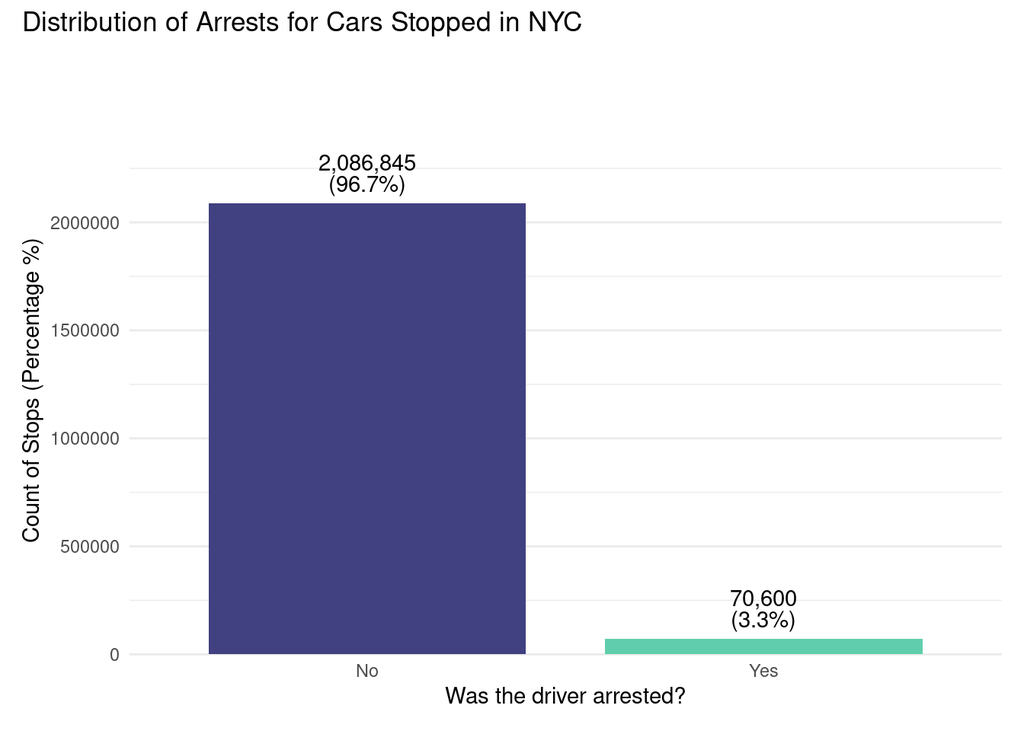

```r
p1 <- plot_binary_bar(
  vehstops, arrested,
  "No", "Yes",
  "Was the driver arrested?", "Count of Stops (Percentage %)", ""
)

row1 <- p1

row1 +
plot_annotation(title = "Distribution of Arrests for Cars Stopped in NYC") &
theme(legend.position = "bottom")
```

What can we say?

What can we say?

- **Key finding**: The dataset for 4-wheels vehicles **exhibits extreme class imbalance** that is even more pronounced than what we observed in the 2-wheels analysis. Arrests are highly sparse, representing only approximately $3.3\%$ of the outcomes ($70,600$ “Yes” out of $2,157,445$ total records) compared to the $5.6\%$ rate found in 2-wheeled vehicle stops.
- **Interpretation**: The target variable constitutes a rare event when we contemplate the stops of 4-wheels vehicles. While the overall volume of stops is drastically higher for 4-wheels vehicles, an arrest remains an infrequent occurrence with respect to the total volume of police stops.
- **Comment**: The high class disparity *makes accuracy a limiting metric* for our models’ evaluation, here too.
- **Proposed Action**: Same as the 2-wheels analysis.

## Geospatial predictors

### Area

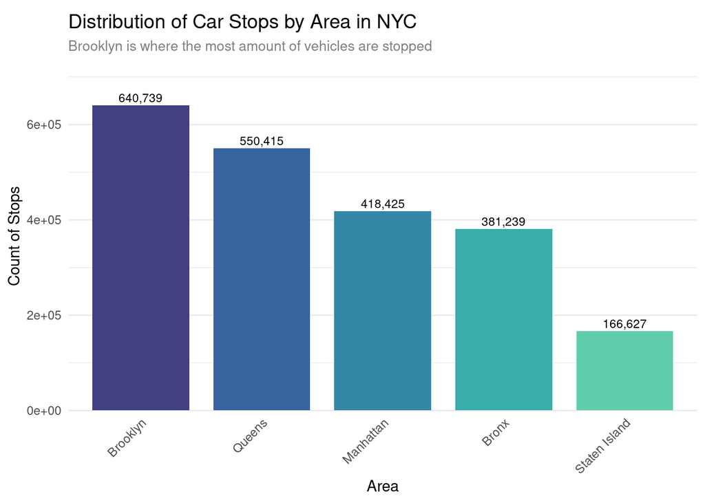

```r
plot_univariate_cat(
  DF = vehstops,
  FEATURE = area,
  X_LABEL = "Area",
  TITLE = "Distribution of Car Stops by Area in NYC",
  SUBTITLE = "Brooklyn is where the most amount of vehicles are stopped",
  order_by = "freq"
)
```

What can we say?

- **Key finding**: Since the bars are distributed by volume, in descending order, we can clearly observe a “ladder” trend in volume. We still have variance, but thanks to the volume we now have a more balanced case. We observe two clear “high-volume” areas (Brooklyn with over $640$k stops and Queens with over $550$k stops) followed by two “medium-volume” areas (Manhattan with $418$k and the Bronx with $381$k) and a distinct “low-volume” area (Staten Island, $166$k).
- **Interpretation**: Compared to the 2-wheels analysis where Staten Island was a tiny outlier ($1.5$k), here it holds a substantial sample size ($166$k). The shifting proportions, particularly the rise of the Bronx into a solid medium-volume category, suggests that geographic location could be a strong predictor of the probability of being stopped (in case the targets’ ratio distributed by area follows a specific pattern).
- **Comment**: Unlike the 2-wheels analysis, Staten Island is not anymore a very rare label, even if the distribution is the lowest among the 5 areas. We have a slightly lower risk of overfitting here, but it is still to early to explore this aspect.
- **Proposed Action**: Same as the 2-wheels analysis.

### Borough

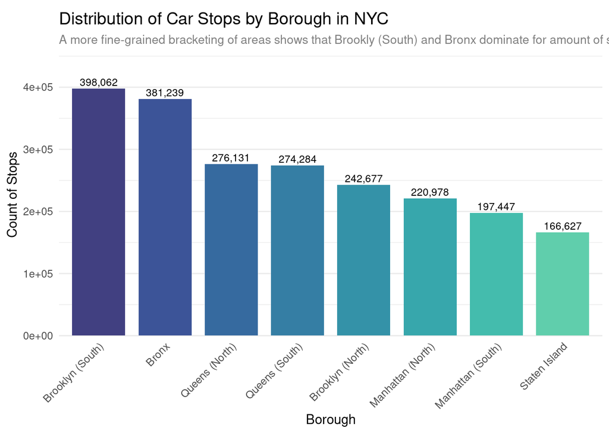

```r
plot_univariate_cat(
  DF = vehstops,
  FEATURE = boro,
  X_LABEL = "Borough",
  TITLE = "Distribution of Car Stops by Borough in NYC",
  SUBTITLE = "A more fine-grained bracketing of areas shows that Brookly (South) and Bronx dominate for amount of stops"
)
```

What can we say?

- **Key finding**: The granular bracketing shows that “Brooklyn (South)” dominates with $398,062$ stops, closely followed by the “Bronx” at $381,239$ stops, whereas in the 2-wheels analysis “North Queens” was the dominant category. Except the top-two volume boroughs, the remaining boroughs seem to have an almost uniform (decreasing) distribution ranging between $166$k - $276$k.
- **Interpretation**: For what concerns granularity, we can draw the same conclsions as the 2-wheels case. On the other hand, since every category contains a massive amount of observations, we probably do not run the risk encountered in the 2-wheels context where low-frequency categories caused high variance and wide confidence intervals in our parameter estimates.
- **Comment**: Same as the 2-wheels analysis.
- **Proposed Action**: Same as the 2-wheels analysis.

### Latitude and Longitude for Stop Density

For what concerns these two predictors, we will use the to plot a spatial heat map of the stops with these values available.

```r
nyc_map <- counties(state = "NY", cb = TRUE) %>%
  filter(NAME %in% c("Bronx", "Kings", "New York", "Queens", "Richmond"))
```

[output not shown]

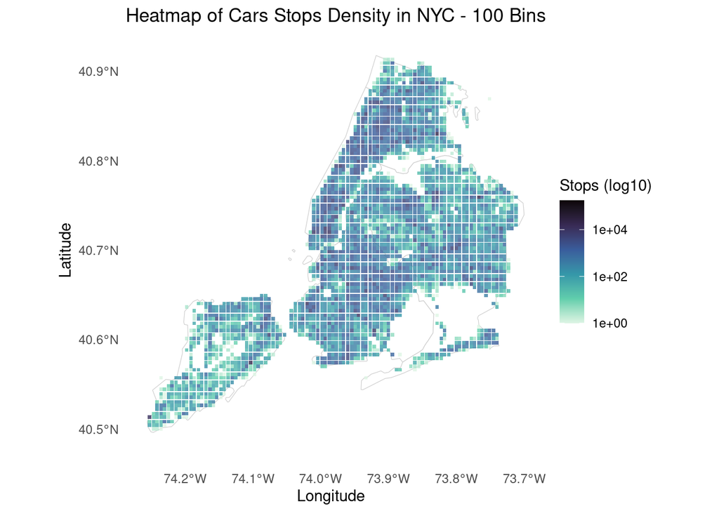

```r
bins <- 100
lon_breaks <- seq(-74.26, -73.71, length.out = bins + 1)
lat_breaks <- seq(40.48, 40.92, length.out = bins + 1)

grid_sum <- vehstops %>%
  filter(!is.na(longitude) & !is.na(latitude)) %>%
  mutate(
    xbin = cut(longitude, breaks = lon_breaks, include.lowest = TRUE, right = FALSE),
    ybin = cut(latitude, breaks = lat_breaks, include.lowest = TRUE, right = FALSE)
  ) %>%
  mutate(
    x = as.numeric(gsub(".*\\[(.*),.*", "\\1", xbin)) + (lon_breaks[2] - lon_breaks[1])/2,
    y = as.numeric(gsub(".*\\[(.*),.*", "\\1", ybin)) + (lat_breaks[2] - lat_breaks[1])/2
  ) %>%
  group_by(x, y) %>%
  summarise(n = n(), .groups = "drop")

ggplot() +
  geom_sf(data = nyc_map, fill = "white", color = "grey80", size = 0.2) +
  geom_tile(data = grid_sum, aes(x, y, fill = n), alpha = 0.8) +
  scale_fill_viridis_c(trans = "log10", name = "Stops (log10)", option = "mako", direction = -1) +
  coord_sf(xlim = c(-74.26, -73.71), ylim = c(40.48, 40.92)) +
  theme_minimal() +
  theme(panel.grid = element_blank()) +
  labs(title = "Heatmap of Cars Stops Density in NYC - 100 Bins", x = "Longitude", y = "Latitude")
```

What can we say?

- **Key finding**: The heatmap reveals that, with respect to the 2-wheels case, the hotspots are the same, although the increase in volume is notable.
- **Interpretation**: Same as the 2-wheels analysis.
- **Proposed Action**: Same as the 2-wheels analysis.

## Time-related predictors

### Year

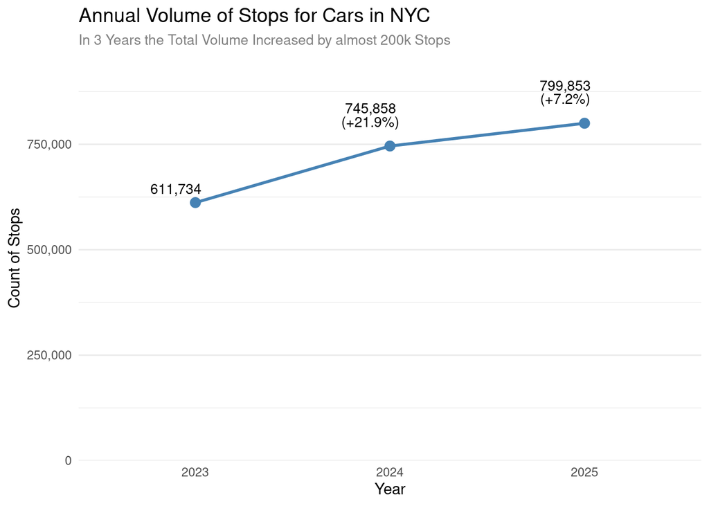

```r
vehstops %>%
  filter(!is.na(year)) %>%
  count(year) %>%
  mutate(year = as.numeric(as.character(year))) %>%
  arrange(year) %>%
  mutate(
    prev_n = lag(n), pct_change = (n - prev_n) / prev_n * 100,
    label_text = ifelse(
      is.na(pct_change),
      comma(n),
      paste0(comma(n), "\n(", ifelse(pct_change > 0, "+", ""), round(pct_change, 1), "%)")
    )) %>%
  ggplot(aes(x = factor(year), y = n, group = 1)) +
  geom_line(color = "steelblue", linewidth = 1) +
  geom_point(color = "steelblue", size = 3) +
  geom_text(aes(label = label_text), vjust = -0.8, nudge_x = -0.1, size = 3.5, lineheight = 0.8) +
  scale_y_continuous(labels = comma, limits = c(0, NA), expand = expansion(mult = c(0, 0.2))) +
  theme_minimal() +
  theme(
    panel.grid.major.x = element_blank(),
    plot.title = element_text(size = 14),
    plot.subtitle = element_text(size = 10, color = "grey50")
    ) +
  labs(
    title = "Annual Volume of Stops for Cars in NYC",
    subtitle = "In 3 Years the Total Volume Increased by almost 200k Stops",
    x = "Year", y = "Count of Stops"
    )
```

What can we say?

- **Key finding**: There has been a steady, multi-year increase in the volume of police stops involving 4-wheeled vehicles, with the absolute number of encounters expanding from $611,734$ in $2023$ to $799,853$ in $2025$. Overall, the volume of stops does not show a very unbalanced distribution among the three years.
- **Interpretation**: The growth trajectory is non-linear but far more stable than the explosive surge seen in the 2-wheels analysis. The $21.9\%$ jump between $2023$ and $2024$ represents a significant upward trend, which is suggesting a broader intensification of traffic enforcement across the city. On the other hand, the $7.2\%$ increase in 2025 indicates that while the absolute volume of activity is still rising, the rate of acceleration is starting to stabilize.
- **Comment**: Same as the 2-wheels analysis.
- **Proposed Action**: Same as the 2-wheels analysis.

### Month

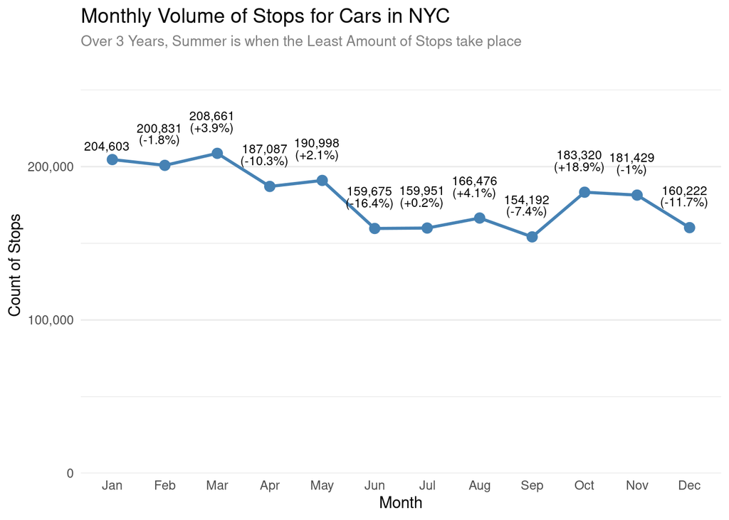

```r
month_data <- vehstops %>%
  filter(!is.na(month)) %>%
  count(month) %>%
  mutate(month = factor(month, levels = 1:12)) %>%
  arrange(month) %>%
  mutate(
    prev_n = lag(n), pct_change = (n - prev_n) / prev_n * 100,
    label_text = ifelse(
      is.na(pct_change), comma(n),
      paste0(comma(n), "\n(", ifelse(pct_change > 0, "+", ""), round(pct_change, 1), "%)"))
  )

month_data %>%
  ggplot(aes(x = month, y = n, group = 1)) +
  geom_line(color = "steelblue", linewidth = 1) +
  geom_point(color = "steelblue", size = 3) +
  geom_text(aes(label = label_text), vjust = -1, nudge_x = -0.1, size = 3, lineheight = 0.8) +
  scale_x_discrete(labels = month.abb) +
  scale_y_continuous(labels = comma, limits = c(0, NA), expand = expansion(mult = c(0, 0.3))) +
  theme_minimal() +
  theme(
    panel.grid.major.x = element_blank(),
    plot.title = element_text(size = 14),
    plot.subtitle = element_text(color = "grey50", size = 10)
  ) +
  labs(
    title = "Monthly Volume of Stops for Cars in NYC",
    subtitle = "Over 3 Years, Summer is when the Least Amount of Stops take place",
    x = "Month",
    y = "Count of Stops"
  )
```

What can we say?

- **Key finding**: The data exhibits a highly distinct monthly pattern for 4-wheels vehicles, contrasting sharply with the June to October summer plateau observed for bikers. Here, stop volumes peak in the early months of the year, reaching an absolute maximum in March at $208,661$ stops, before experiencing a plateau, starting in June, that bottoms out in September at $154,192$ stops (a $-7.4\%$ drop from August).
- **Interpretation**: Unlike 2-wheeled vehicles, **4-wheeled vehicles are stopped regardless of the season and the related weather conditions**. This explains the high volume baseline maintained in January ($204,603$) and February ($200,831$). The steady downward trajectory into June ($-16.4\%$) and July may suggest a shift in enforcement.
- **Comment**: Most of the conclusions we can make here come from the 2-wheels analysis. The interesting aspect is that the peaks are almost completely counter-cyclical to the 2-wheels plot. This may suggest that, for standard automobiles, the police behavior shows a mechanic that is entirely independent from seasonal weather. If this was true, we could not compare fairly the two datasets.
- **Proposed Action**: Same as the 2-wheels analysis.

Let us see this with respect to the year

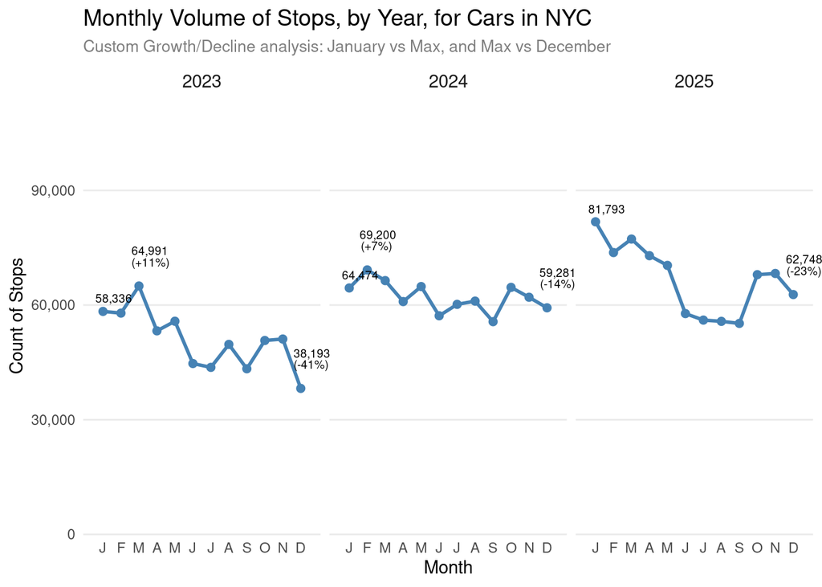

```r
plot_data <- vehstops %>%
  filter(!is.na(year) & !is.na(month)) %>%
  count(year, month) %>%
  mutate(month = factor(month, levels = 1:12)) %>%
  group_by(year) %>%
  mutate(
    n_jan = n[month == 1],
    n_max = max(n),
    is_max = n == n_max,
    pct_max = round((n - n_jan) / n_jan * 100, 0),
    pct_dec = round((n - n_max) / n_max * 100, 0),

    label_text = case_when(
      month == 1 ~ comma(n),
      is_max ~ paste0(comma(n), "\n(", ifelse(pct_max > 0, "+", ""), pct_max, "%)"),
      month == 12 ~ paste0(comma(n), "\n(", pct_dec, "%)"),
      TRUE ~ ""
    )
  )

# Faceted plot
plot_data %>%
  ggplot(aes(x = month, y = n, group = 1)) +
  geom_line(color = "steelblue", linewidth = 1) +
  geom_point(color = "steelblue", size = 2) +
  geom_text(aes(label = label_text), vjust = -1, hjust = 0.2, size = 2.5, lineheight = 0.8) +
  facet_wrap(~year, nrow = 1) +
  scale_x_discrete(
    labels = c("J", "F", "M", "A", "M", "J", "J", "A", "S", "O", "N", "D"),
    expand = expansion(mult = c(0.1, 0.1))
    ) +
  scale_y_continuous(labels = comma, limits = c(0, NA), expand = expansion(mult = c(0, 0.4))) +
  coord_cartesian(clip = "off") +
  theme_minimal() +
  theme(
    panel.grid.major.x = element_blank(),
    panel.grid.minor = element_blank(),
    plot.title = element_text(size = 14),
    plot.subtitle = element_text(color = "grey50", size = 10),
    strip.text = element_text(size = 11)
  ) +
  labs(
    title = "Monthly Volume of Stops, by Year, for Cars in NYC",
    subtitle = "Custom Growth/Decline analysis: January vs Max, and Max vs December",
    x = "Month",
    y = "Count of Stops"
  )
```

What can we say?

- **Key finding**: There is a pronounced shifting trend in the intra-year volume distribution over the three-year period. In $2023$, the annual maximum occurred early in March ($64,991$, an $11\%$ increase from January) followed by a sharp drop to December ($38,193$, a $-41\%$ decline). In $2024$ the monthly amount of stops follows a slightly decreasing trend. By $2025$, the behavior changes, as the year begins at a much higher baseline peak in January ($81,793$). Then it shows a steep mid-year contraction through summer, and it ends with a surge (in October) that leads to a much softer winter decline by December ($62,748$, a $-23\%$ drop from the annual maximum).
- **Interpretation**: The data indicates that enforcement patterns for 4-wheels vehicles are having structural adjustments over the years, although the overall volume keeps increasing. The widening gap between the high-volume peaks and the low-volume troughs seen in the 2-wheels context does not apply here. Instead, the “off-season” drop in December is becoming significantly less severe, moving from $-41\%$ in $2023$ to $-23\%$ in $2025$, which implies a stabilization of late-year policing activities.
- **Comment**: The plot clearly shows that while the baseline (January) is rising substantially over the years. Furthermore, we notice that the *shape* of the annual trend is shifting from looking like a spring, to a 2-phase distribution with a notable winter increase. This shift confirms our hypothesis that seasonal **vehicle usage is not the primary factor** for stops. Instead, this is probably due to the policy shifts within the police department.
- **Proposed Action**: Here is impossible to include the same `hot_season` factor, as we would like to restrict the focus months over the June-September period. Therefore, we skip it.

### Dow/Weekday, Day and Doy

We have decided to exclude ‘Day of Month’ (`day`) and ‘Day of Year’ (`doy`) from our feature set to mitigate ‘calendar artifact’ bias.

As we can see below, the variation in month length creates false activity dips for end-of-month dates

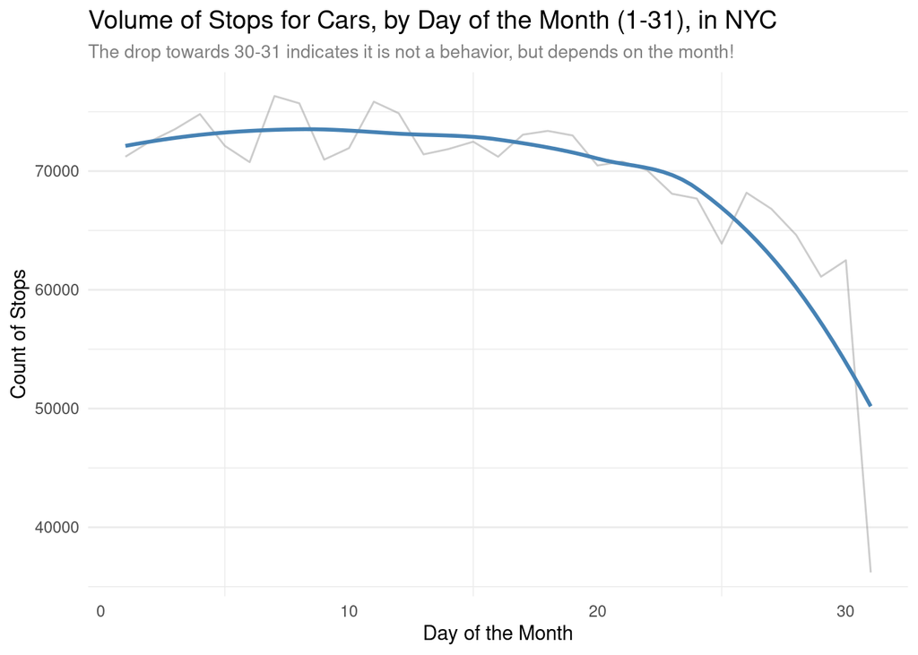

```r
vehstops %>%
  filter(!is.na(day)) %>%
  count(day) %>%
  ggplot(aes(x = day, y = n)) +
  geom_line(color = "grey60", alpha = 0.5) +
  geom_smooth(method = "loess", color = "steelblue", se = FALSE) +
  theme_minimal() +
   theme(
    panel.grid.major.x = element_blank(),
    plot.title = element_text(size = 14),
    plot.subtitle = element_text(color = "grey50", size = 10)
  ) +
  labs(title = "Volume of Stops for Cars, by Day of the Month (1-31), in NYC",
       subtitle = "The drop towards 30-31 indicates it is not a behavior, but depends on the month!",
       x = "Day of the Month", y = "Count of Stops")
```

Furthermore, `doy` variable suffers from inconsistent data density.

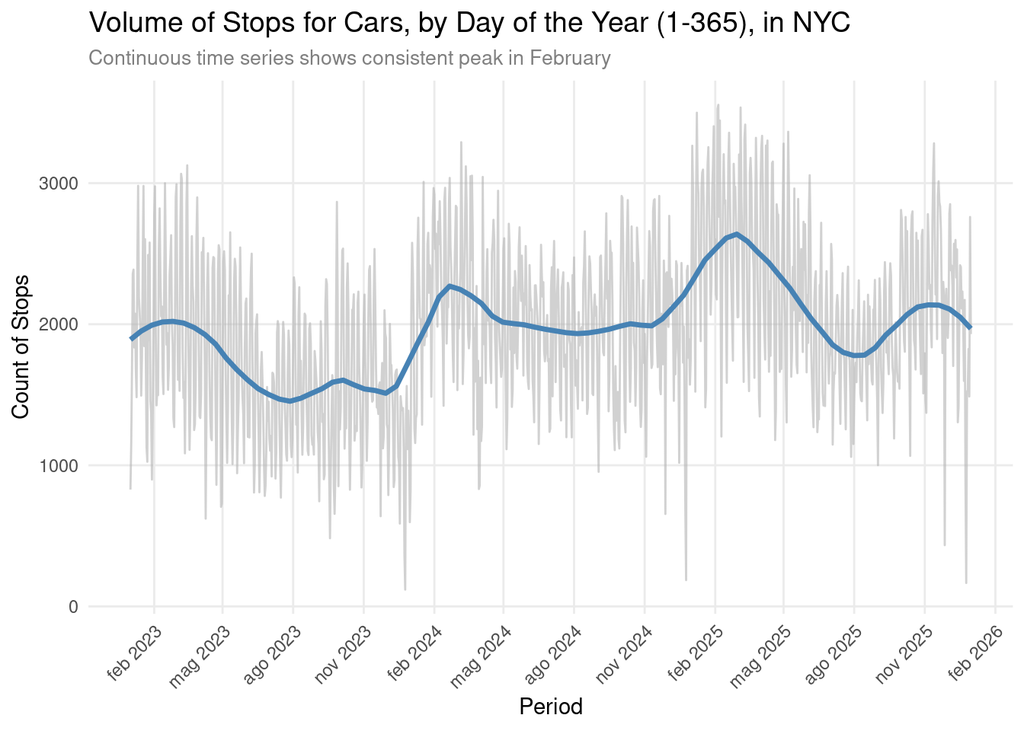

```r
plot_data <- vehstops %>%
  mutate(date = as.Date(paste(year, month, day, sep = "-"))) %>%
  count(date)

plot_data %>%
  ggplot(aes(x = date, y = n)) +
  geom_line(color = "grey70", alpha = 0.6, linewidth = 0.5) +
  geom_smooth(method = "loess", span = 0.2, color = "steelblue", se = FALSE, linewidth = 1.2) +
  scale_x_date(date_breaks = "3 months", date_labels = "%b %Y") +
  theme_minimal() +
  theme(
    panel.grid.minor = element_blank(),
    axis.text.x = element_text(angle = 45, hjust = 1),
    plot.title = element_text(size = 14),
    plot.subtitle = element_text(color = "grey50", size = 10)
  ) +
  labs(
    title = "Volume of Stops for Cars, by Day of the Year (1-365), in NYC",
    subtitle = "Continuous time series shows consistent peak in February",
    x = "Period",
    y = "Count of Stops"
  )
```

While we observe a consistent seasonal clustering peaking in late winter and early spring, our current 3-year dataset captures three seasonal cycles. This is sufficient to identify a recurring pattern, but insufficient to establish it as a long-term trend.

The next plot, demonstrates high daily volatility (indicated by the grey jitter) that obscures the underlying seasonal trend (the blue trend line). Because the daily fluctuation is relative to the overall pattern, including ‘Day of Year’ as a feature risks overfitting.

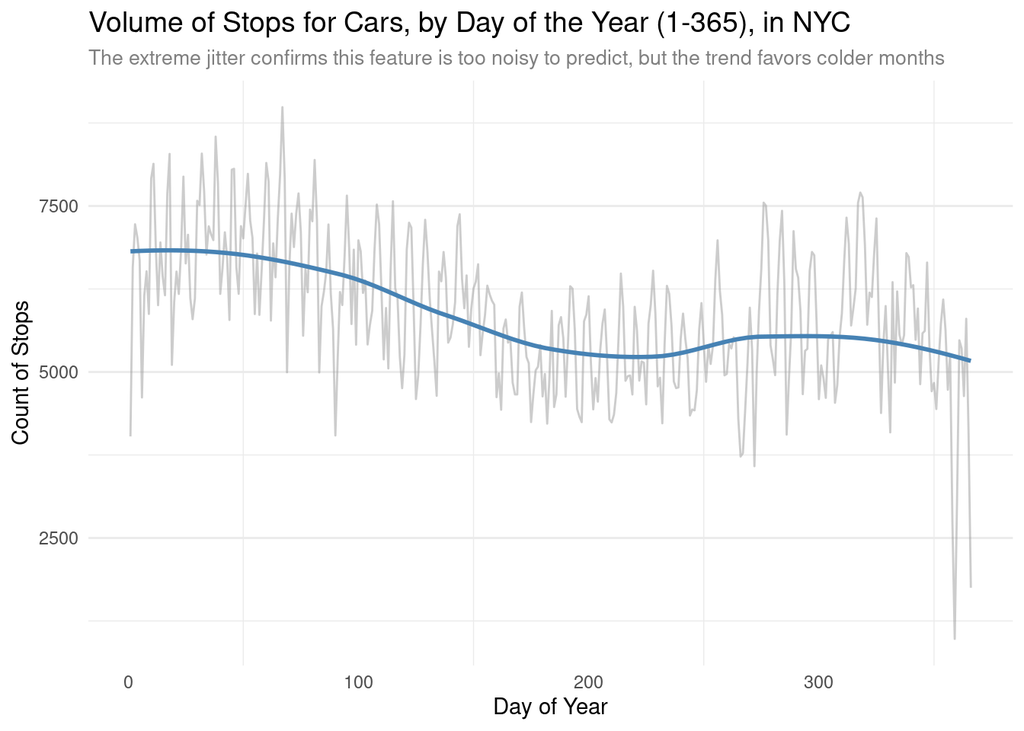

```r
vehstops %>%
  filter(!is.na(doy)) %>%
  count(doy) %>%
  ggplot(aes(x = doy, y = n)) +
  geom_line(color = "grey60", alpha = 0.5) +
  geom_smooth(method = "loess", color = "steelblue", se = FALSE) +
  theme_minimal() +
   theme(
    panel.grid.major.x = element_blank(),
    plot.title = element_text(size = 14),
    plot.subtitle = element_text(color = "grey50", size = 10)
  ) +
  labs(title = "Volume of Stops for Cars, by Day of the Year (1-365), in NYC",
       subtitle = "The extreme jitter confirms this feature is too noisy to predict, but the trend favors colder months",
       x = "Day of Year", y = "Count of Stops")
```

The extreme jitter confirms this feature is too noisy to predict, but unlike the 2-wheels analysis where the trend favors hot months, the 4-wheels trend remains relatively elevated in the first half of the year before dipping during the summer months.

On the other hand, we can study the “Day of the Week” which usually abstract better.

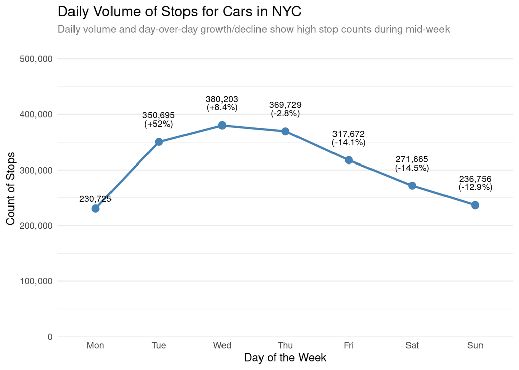

```r
vehstops %>%
  filter(!is.na(dow)) %>%
  count(dow) %>%
  mutate(
    dow = factor(dow, levels = 1:7,
                 labels = c("Mon", "Tue", "Wed", "Thu", "Fri", "Sat", "Sun")),
    pct_change = (n - lag(n)) / lag(n) * 100,
    label_text = ifelse(is.na(pct_change),
                        comma(n),
                        paste0(comma(n), "\n(", ifelse(pct_change > 0, "+", ""), round(pct_change, 1), "%)"))
  ) %>%
  ggplot(aes(x = dow, y = n, group = 1)) +
  geom_line(color = "steelblue", linewidth = 1) +
  geom_point(color = "steelblue", size = 3) +
  geom_text(aes(label = label_text), vjust = -1, size = 3, lineheight = 0.8) +
  scale_y_continuous(labels = comma,
                     limits = c(0, NA),
                     expand = expansion(mult = c(0, 0.4))) +
  theme_minimal() +
  theme(
    panel.grid.major.x = element_blank(),
    plot.title = element_text(size = 14),
    plot.subtitle = element_text(color = "grey50", size = 10)
  ) +
  labs(
    title = "Daily Volume of Stops for Cars in NYC",
    subtitle = "Daily volume and day-over-day growth/decline show high stop counts during mid-week",
    x = "Day of the Week",
    y = "Count of Stops"
  )
```

What can we say?

- **Key finding**: Enforcement activity follows a distinct “Mid-Week Peak” cycle that strongly mirrors the weekly rhythm seen in the 2-wheels analysis. The volume starts at its absolute lowest on Monday ($230,725$), raises aggressively ($+52\%$) into Tuesday ($350,695$), peaks on Wednesday at $380,203$ stops ($+8.4\%$), and then undergoes a multi-day decline through the end of the week, bottoming out on Sunday ($236,756$).
- **Comment**: Same as the 2-wheels analysis.
- **Proposed Action**: Same as the 2-wheels analysis.

### Hour and Time Bracket

First of all we look at the overall cycle of stops volume

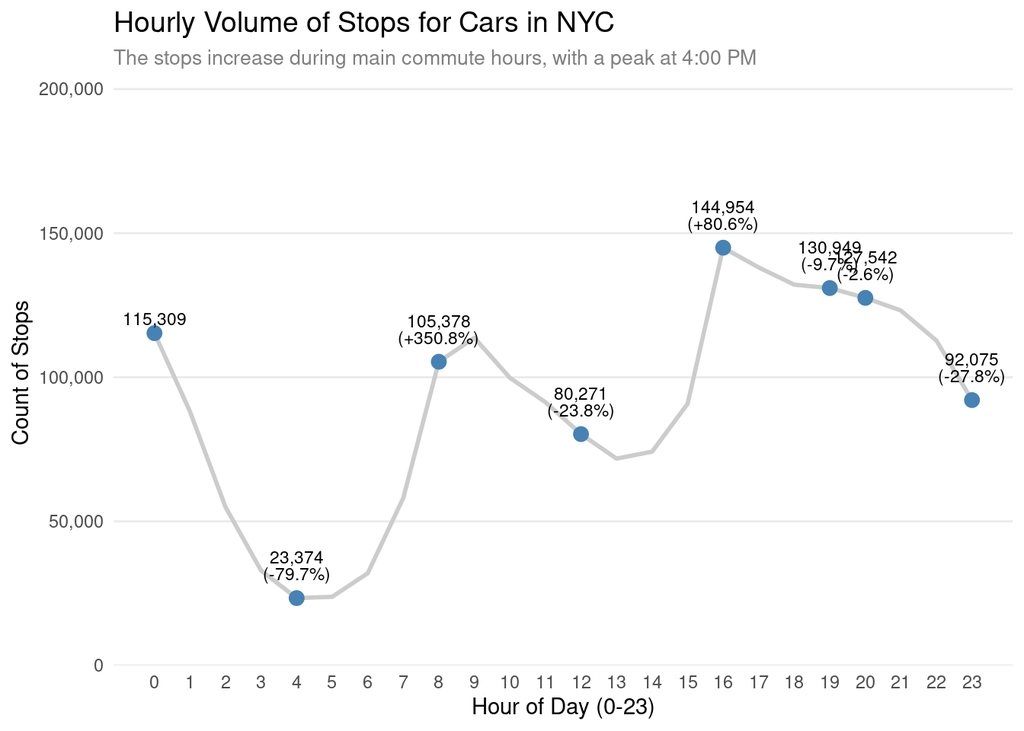

```r
hours_to_show <- c(0, 4, 8, 12, 16, 19, 20, 23)

full_data <- vehstops %>%
  filter(!is.na(hour)) %>%
  count(hour)

highlight_data <- full_data %>%
  filter(hour %in% hours_to_show) %>%
  arrange(hour) %>%
  mutate(
    pct_change = (n - lag(n)) / lag(n) * 100,
    label_text = ifelse(
      is.na(pct_change),
      comma(n),
      paste0(comma(n), "\n(", ifelse(pct_change > 0, "+", ""), round(pct_change, 1), "%)"))
  )

ggplot() +
  geom_line(data = full_data, aes(x = hour, y = n), color = "grey80", linewidth = 1) +
  geom_point(data = highlight_data, aes(x = hour, y = n), color = "steelblue", size = 3) +
  geom_text(data = highlight_data, aes(x = hour, y = n, label = label_text),
            vjust = -0.6, size = 3, lineheight = 0.8) +
  scale_x_continuous(breaks = 0:23) +
  scale_y_continuous(labels = comma, limits = c(0, NA), expand = expansion(mult = c(0, 0.4))) +
  theme_minimal() +
  theme(
    panel.grid.major.x = element_blank(),
    panel.grid.minor = element_blank(),
    plot.title = element_text(size = 14),
    plot.subtitle = element_text(color = "grey50", size = 10)
  ) +
  labs(
    title = "Hourly Volume of Stops for Cars in NYC",
    subtitle = "The stops increase during main commute hours, with a peak at 4:00 PM ",
    x = "Hour of Day (0-23)",
    y = "Count of Stops"
  )
```

What can we say?

- **Key finding**: Volume of stops is characterized by a 3-stages daily cycle. First, it follows a night time decline towards an absolute minimum at $4:00$ ($23,374$, a $-79.7\%$ drop with respect to $00:00$). Then, we have a rapid morning ascent to before localized peak at $9:00$ (at $8:00$ we have $105,378$, which is an increase of $+350.8\%$ w.r.t. 4 AM), followed by a midday decline before a rapid afternoon surge to an absolute peak at $16:00$ ($144,954$, $+80.6\%$ w.r.t. 12 PM), and a sustained high-volume evening plateau before tailing off late at night.
- **Interpretation**: This distribution indicates that the enforcement cycle is driven by three phases: the **Morning Commuter Phase** (centered around $8:00$), the **Midday Transition Phase** (which causes the temporary dip down to $80,271$ at $12:00$), and the **Late Afternoon Rush Phase** (surging aggressively to the absolute peak at $16:00$ and tapering slowly through the evening hours). Unlike the 2-wheels analysis, the 4-wheels data shows shifts that perfectly align with major automotive traffic shifts throughout the city.
- **Proposed Action**: We will maintain `hour` as a temporal feature in our predictive framework. As an alternative, we *could* try to properly capture this pattern. For instance, we could **transform the continuous hour variable using a periodic basis function**, so that it becomes a continuous feature.

Before anything else, let us see whether this cycle changed throughout the years.

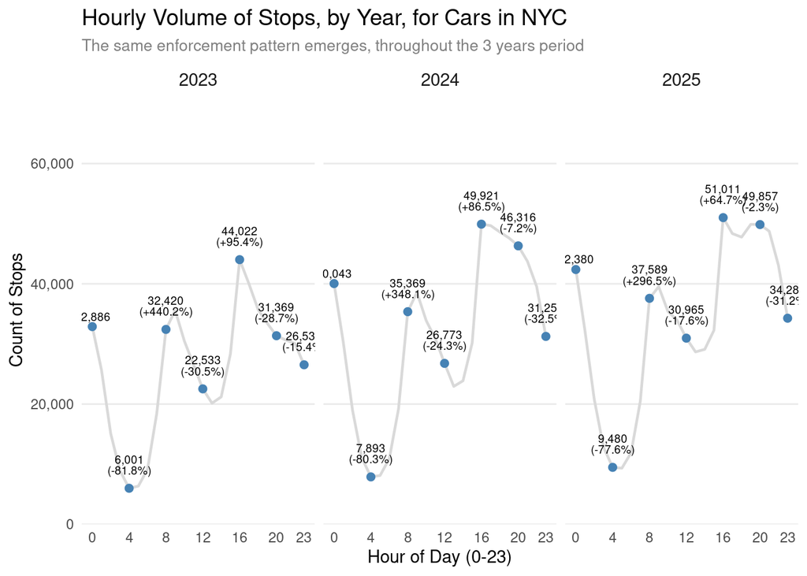

```r
hours_to_show <- c(0, 4, 8, 12, 16, 20, 23)

full_data <- vehstops %>%
  filter(!is.na(year) & !is.na(hour)) %>%
  count(year, hour)

highlight_data <- full_data %>%
  filter(hour %in% hours_to_show) %>%
  group_by(year) %>%
  arrange(hour) %>%
  mutate(
    pct_change = (n - lag(n)) / lag(n) * 100,
    label_text = ifelse(
      is.na(pct_change),
      comma(n),
      paste0(comma(n), "\n(", ifelse(pct_change > 0, "+", ""), round(pct_change, 1), "%)"))
  )

ggplot() +
  geom_line(data = full_data, aes(x = hour, y = n), color = "grey85", linewidth = 0.8) +
  geom_point(data = highlight_data, aes(x = hour, y = n), color = "steelblue", size = 2) +
  geom_text(data = highlight_data, aes(x = hour, y = n, label = label_text),
            vjust = -0.7, size = 2.5, lineheight = 0.8) +
  facet_wrap(~year, nrow = 1) +
  scale_x_continuous(breaks = c(0, 4, 8, 12, 16, 20, 23)) +
  scale_y_continuous(labels = comma, limits = c(0, NA), expand = expansion(mult = c(0, 0.4))) +
  theme_minimal() +
  theme(
    panel.grid.major.x = element_blank(),
    panel.grid.minor = element_blank(),
    plot.title = element_text(size = 14),
    plot.subtitle = element_text(color = "grey50", size = 10),
    strip.text = element_text(size = 11)
  ) +
  labs(
    title = "Hourly Volume of Stops, by Year, for Cars in NYC",
    subtitle = "The same enforcement pattern emerges, throughout the 3 years period",
    x = "Hour of Day (0-23)",
    y = "Count of Stops"
  )
```

What can we say?

- **Key finding**: Across all the three years, the enforcement volume shows the same pattern as stated for the previous plot, except for the period that goes from $16:00$ to $23:00$ which seems to be shifting. Two aspects remain evident: there are a minor peak during the morning rush at $8:00$ and a dominant peak during the late afternoon and evening. In $2023$ and $2024$, the absolute highest volume of stops occurred at $16:00$ ($4:00$ PM). By $2025$, while the $16:00$ peak remains the highest absolute value ($51011$ stops), the volume remains high and remains nearly unchanged until $20:00$ with $49857$ stops.
- **Interpretation**: Unlike what we observed for two-wheeled vehicles, car stops maintain a consistent primary afternoon peak at $16:00$ across the entire $2023$ to $2025$ period. The increase in volume at $20:00$ in $2025$ suggests that evening traffic enforcement has been growing. Instead, the morning rush hour peak at $8:00$ remains stable in structure across all years.

Let us check the time brackets previously built.

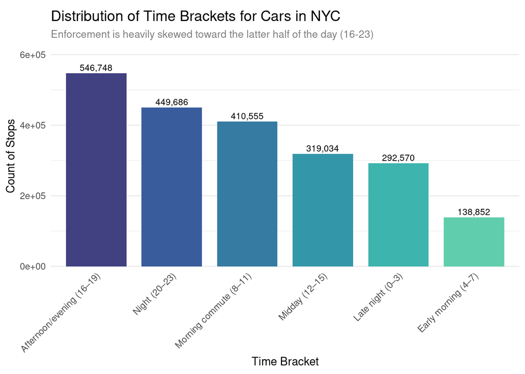

```r
plot_univariate_cat(
  DF = vehstops,
  FEATURE = time_bracket,
  X_LABEL = "Time Bracket",
  TITLE = "Distribution of Time Brackets for Cars in NYC",
  SUBTITLE = "Enforcement is heavily skewed toward the latter half of the day (16-23)"
)
```

What can we say?

- **Key finding**: The “Afternoon/evening ($16-19$)” bracket stands as the absolute dominant peak with $546,748$ stops, closely followed by the “Night ($20-23$)” and “Morning commute ($8-11$)” brackets with $449,686$ and $410,555$ stops respectively. The lowest volume is in the “Early morning ($4-7$)” window that registers just $138,852$ stops.
- **Interpretation**: Just like for 2-wheels vehicles, the volume of enforcement is tied around the latter half of the day ($16-23$), which confirm the pattern shown by the previous bar plots.
- **Comment**: In contrast to the two-wheeled vehicle analysis, the car data shows a smoother distribution.
- **Proposed Action**: We can safely maintain our existing `time_bracket` feature engineering exactly as it is for the upcoming modeling phase.

Also, we are going to drop minute as its level of granularity cannot be properly included in the dataset.

## Driver related predictors

### Reported Age

We have mainly one issue here. First, we have many instances of drivers with unknown age,

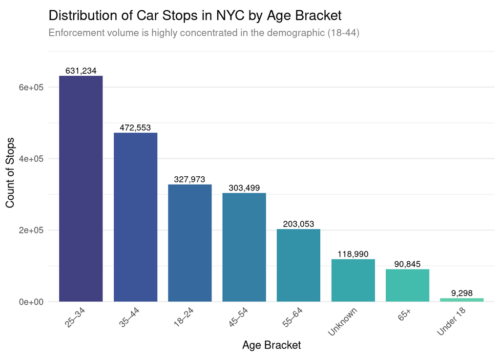

```r
plot_univariate_cat(
  DF = vehstops,
  FEATURE = age_bracket,
  X_LABEL = "Age Bracket",
  TITLE = "Distribution of Car Stops in NYC by Age Bracket",
  SUBTITLE = "Enforcement volume is highly concentrated in the demographic (18-44)"
)
```

What can we say?

- **Key finding**: The demographic distribution of stops is highly concentrated in the $25-34$ age category with $631,234$ observations, followed by the $35-44$ and $18-24$ brackets. Furthermore, the “Unknown” age category represents a significant portion with $118,990$ records, while the “Under 18” category is the smallest group with just $9298$ stops.
- **Interpretation**: Although, older age groups show lower frequency, they are much more well-represented here compared to the two-wheeled vehicle analysis. In fact, most categories are well represented here too.
- **Comment**: Same as 2-wheels analysis.
- **Proposed Action**: We will retain the “Unknown” category as a level within our `age_bracket` feature rather than using imputation.

And now, let us see how this looks when looking at the full distribution

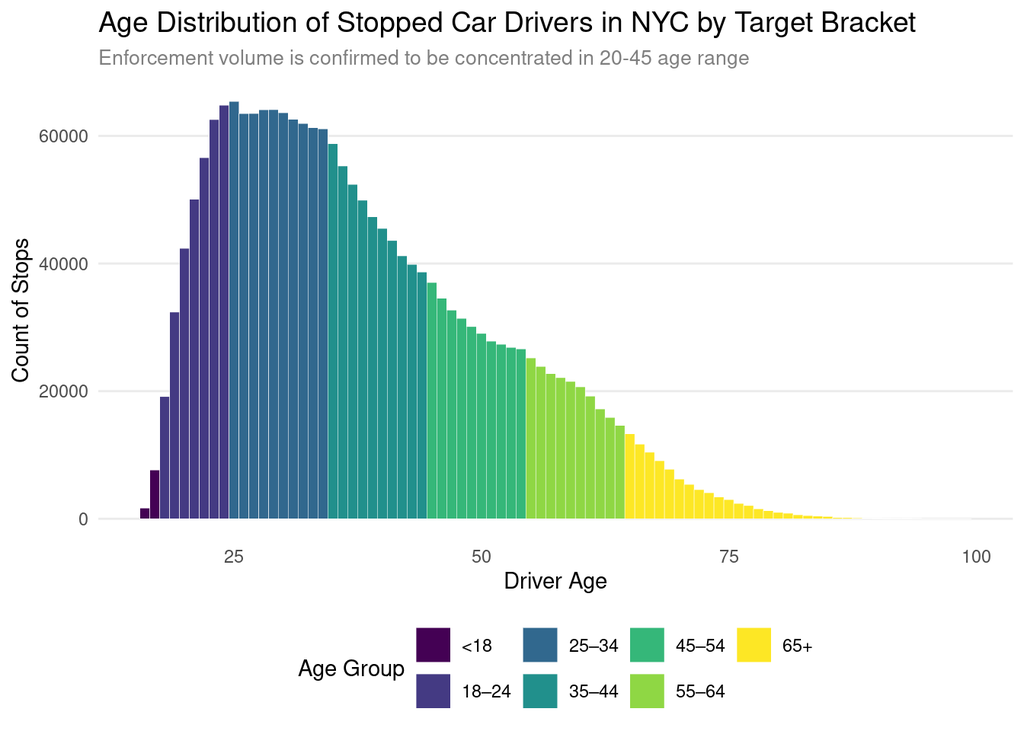

```r
age_data <- vehstops %>%
  filter(!is.na(age), age >= 0, age < 100) %>%
  mutate(
    age_group = case_when(
      age < 18 ~ "<18",
      age >= 18 & age <= 24 ~ "18–24",
      age >= 25 & age <= 34 ~ "25–34",
      age >= 35 & age <= 44 ~ "35–44",
      age >= 45 & age <= 54 ~ "45–54",
      age >= 55 & age <= 64 ~ "55–64",
      age >= 65 ~ "65+"
    ),
    age_group = factor(age_group, levels = c("<18", "18–24", "25–34", "35–44", "45–54", "55–64", "65+"))
  )

ggplot(age_data, aes(x = age, fill = age_group)) +
  geom_histogram(binwidth = 1, color = "white", linewidth = 0.1) +
  scale_fill_viridis_d() +
  theme_minimal() +
   theme(
    panel.grid.major.x = element_blank(),
    panel.grid.minor = element_blank(),
    plot.title = element_text(size = 14),
    plot.subtitle = element_text(color = "grey50", size = 10),
    strip.text = element_text(size = 11)
  ) +
  labs(
    title = "Age Distribution of Stopped Car Drivers in NYC by Target Bracket",
    subtitle = "Enforcement volume is confirmed to be concentrated in 20-45 age range",
    x = "Driver Age",
    y = "Count of Stops",
    fill = "Age Group"
  ) +
  theme(legend.position = "bottom") +
  guides(fill = guide_legend(nrow = 2))
```

What can we say?

- **Key finding**: The enforcement volume shows a rapid increase, from the underage year, that becomes a sustained plateau that spans from around the age $23$ through age $35$. Here, most age labels can count on more than $60000$ stops. After the age of $35$, the volume starts to steadily decline through middle age. After that, it shifts into a long tail that, past age $75$, becomes extremely flat.
- **Comment**: The four-wheel stops distribution show a **much broader plateau**, with respect to the 2-wheels analysis, which is probably due to the higher concentration of older drivers (hinted by the slow decreasing pattern).
- **Proposed Action**: Same as 2-wheels analysis, even if here the best thing to do is to filter over $85$, but we want it to be comparable with the other analysis.

Let us remove the outliers

```r
# Keep the NAs
vehstops <- vehstops %>%
  filter(age < 76 | is.na(age))
```

From now on we will consider drivers of age in the range 16-75.

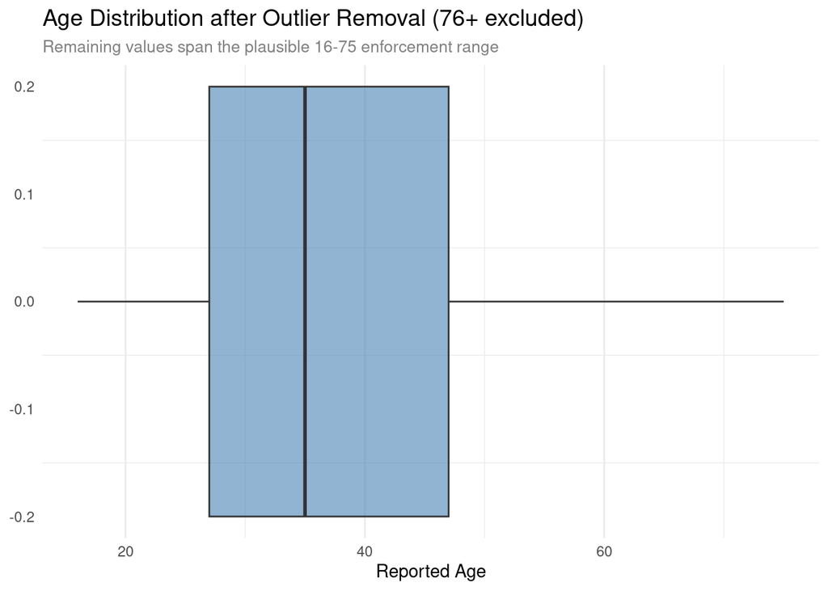

```r
vehstops %>%
  filter(!is.na(age)) %>%
  ggplot(aes(y = age)) +
  geom_boxplot(fill = "steelblue", alpha = 0.6, width = 0.4,
               outlier.size = 1.5, outlier.alpha = 0.4) +
  coord_flip() +
  theme_minimal() +
  theme(
    panel.grid.major.y = element_blank(),
    plot.title = element_text(size = 14),
    plot.subtitle = element_text(color = "grey50", size = 10)
  ) +
  labs(
    title = "Age Distribution after Outlier Removal (76+ excluded)",
    subtitle = "Remaining values span the plausible 16-75 enforcement range",
    y = "Reported Age", x = NULL
  )
```

What can we say?

- **Key finding**: The median is centered around $35$, with the interquartile range ($IQR$) stretching roughly from $27$ to $47$. The lower whisker reaches near the minimum legal driving age, and the upper whisker gets up to $75$ without showing any point as outlier.
- **Interpretation**: The fact that the $IQR$ spans $27-47$ reflects the increased presence of older drivers in the car dataset.
- **Comment**: While the boxplot for the two-wheeled vehicle analysis shows sparsity for older drivers ($65-75$), here the car data does not label them as possible outliers for the current distribution.
- **Proposed Action**: Same as 2-wheels analysis.